# Exploring Walleye Population Decline in Wisconsin’s Lakes

Michael Mays

Originally prepared: May 2020

```r
knitr::opts_chunk$set(echo = F, message=F,
                      warning=F, fig.width=10,
                      out.width="\\linewidth")

# Always helpful libraries
library(tidyverse)
library(broom)
library(broom.mixed)

# Model fitting libraries
library(lme4)
library(lmerTest)
library(glmmTMB)
suppressWarnings(library(DHARMa))
library(MASS) # For rnegbin()
library(optimx)

# For ROC functions and createFolds function
library(pROC)
library(caret)

# Plotting libraries
library(sjPlot)
library(cowplot)
library(ggeffects)

source("helper_functions.R") # Various functions created for use in this project
source("data.R") # All of the data reading/cleaning/etc

# Just some ggplot theme options I tend to like
theme_general <- theme(panel.background =
                         element_rect(fill="white"),
                       plot.background =
                         element_rect(fill="white"),
                       panel.grid.major.x = element_blank(),
                       panel.grid.minor.x = element_blank(),
                       panel.grid.major.y =
                         element_line(color = "gray80"),
                       panel.grid.minor.y =
                         element_line(color = "gray80",
                                      linetype="dotted"),
                       axis.ticks = element_blank(),
                       legend.position = "right",
                       legend.background =
                         element_rect(fill="white"),
                       legend.text=element_text(size=16),
                       legend.title=element_text(size=16),
                       plot.title = element_text(size = 16,
                                                 face = "bold",
                                                 hjust = 0.5),
                       plot.subtitle = element_text(hjust = 0.5),
                       axis.title.y =
                         element_text(size=16,
                                      margin=margin(0,10,0,0)),
                       axis.title.x =
                         element_text(size=16,
                                      margin=margin(10,0,0,0)),
                       axis.text.y = element_text(size=12),
                       axis.text.x = element_text(size=12),
                       strip.text.y =
                         element_text(size = 15))
```

# Background & Introduction

Northern Wisconsin walleye (*Sander vitreus*) are vital to numerous economic, recreational, and cultural activities in the state, particularly in the Ceded Territory occupied by the Lake Superior Chippewa Tribes. After Wisconsin affirmed the treaty rights of the state’s Indigenous peoples to off-reservation fishing, hunting, and gathering in 1985, the Wisconsin Department of Natural Resources (WDNR) has taken up the task of managing and monitoring the state’s walleye stocks in partnership with the Great Lakes Indian Fish and Wildlife Commission since 1987. Recently, however, WDNR and academics who monitor walleye populations have raised concerns over the long-term sustainability of walleye stocks. In particular, WDNR’s 2016 report noted that “the proportion of lakes with YOY catch rates greater than 25 or 100 fish per [shoreline] mile in 2016 was less than the mean proportion of lakes observed with the same catch rates between 1990-2015” (Cichosz 2018, pp. 39). Although there is some consensus that rising water temperatures and increases in largemouth bass populations have strong relationships with the rate of decline (for example, G. J. A. Hansen et al. 2017), the broader causes remain unclear.

The purpose of this project is to examine whether and to what extent walleye recruitment has declined over time, identify the types of lakes in which any such decline is occurring, and—if possible—tease out its potential causes. In particular, I focus on the effects of abiotic factors such as water conditions and temperature, as opposed to biotic factors like predators, on the recruitment of age-0 (known as young-of-the-year, or YOY) and age-1 (juvenile, or JUV) walleye. To do so, I use two models—a negative binomial generalized linear model and a zero-inflated generalized linear mixed model—to detect trends in the populations of age-0 and age-1 walleye since 1990. Additional research questions sought to determine whether any such trends were constant, and whether they were concentrated in certain types of lakes.

# Data

The data set analyzed included measurements of 14 variables for each of 171 Wisconsin lake-years, plus the name and ID of each lake, as well as the year it was sampled. The variables included in the data set were:

- the length of shoreline surveyed (in meters);
- the number of YOY walleye recruited and the YOY recruited per meter of surveyed shoreline; the number of juvenile walleye recruited;
- the temperature (in degrees F) when the survey was conducted;
- the size of each lake (in acres);
- the maximum depth of each lake (in meters);
- a classifier for each lake based on how water enters it (seepage, spring, or drainage);
- a classifier for the overall water clarity of each lake (from very low to very clear);
- Secchi satellite depth (a quantitative water clarity measurement based on the maximum depth in meters at which a disk can be seen by a satellite when dropped in the lake);
- the water’s conductivity (in micro Seimens per centermeter);
- the lake’s growing degree days (DD), which measures the accumulated length of time (in days) the lake was above the reference temperature of 5 degrees C;
- the mean temperature at the bottom of the lake (in degrees C) in June for the survey year; and
- ice duration days, which is the length of time (in days) the lake spent iced over in the survey year.

```r
fish <- read_csv("fish.csv") %>%
  drop_na() %>%
  mutate(
    wbic = as.factor(wbic), # Convert characters to factors
    lake_type = as.factor(lake_type),
    clarity = as.factor(clarity),
    yoy_per_acre = yoy_catch/size_acre,
    yoy_per_km = yoy_per_meter*1000, # Convert m to km
    recruit_yoy = ifelse(yoy_per_km>6.2, 1, 0), # Success binary
    recruit_yoy = as.factor(recruit_yoy), # Make success a factor
    temp_survey_c = ((temp_survey-32)*(5/9)) # F to C
  ) %>%
  filter(clarity!="Very Low", # Remove one "Very Low" clarity obs
         wbic!=2294900#, # Remove TURTLE-FLAMBEAU FL because it is
         # an outlier
  )

# Data with scaled temperature variables to help
#   the more complicated models converge faster
fish_sc <- fish %>%
  mutate(log_km_surv = log(meters_surv/1000),
         f_year = as.factor(year),
         s_year = (year-min(year)),
         log_size_acre = log(size_acre)) %>%
  mutate_at(.vars=c("temp_survey",
                    "gdd_wtr_5c"), .funs = scale)

# Data with scaled temps and
#   - log'd acreage for use as an offset
#   - year scaled down such that the baseline year (1990) is 0
ft <- fish %>%
  mutate(size_acre=log(size_acre),
         s_year = (year-(min(year)))) %>%
  mutate_at(.vars=c("temp_survey",
                    "gdd_wtr_5c"), .funs = scale)

# Data without zero-valued YOY obs and
#   - km surveyed
#   - log'd survey km for use as an offset
#   - year scaled down such that the baseline year (1990) is 0
fish_nz <- fish %>%
  filter(yoy_catch!=0) %>%
  mutate(km_surv = meters_surv/1000,
         log_km_surv = log(km_surv),
         s_year = year-(min(year)+1))
```

There were no duplicated lake-years.

```r
sum(duplicated(fish[,c(1,3)]))
```

```
## [1] 0
```

```r
sum(fish$temp_survey_c<10|fish$temp_survey_c>21)
```

```
## [1] 0
```

# Statistical Models

I fit two models to assess YOY recruitment and one to assess JUV recruitment. They are detailed below.

## Log-Normal (YOY)

```r
# Normal errors, random effect for year
g <- lmer(log(yoy_catch+juv_catch)~
            I(s_year) +
            I(s_year^2) +
            (1|wbic)+
            log(size_acre),
          data=fish_nz)

s_norm <- summary(g)
```

This model is parameterized as:

$$\begin{align*}
ln(y_{i\ell}^\prime) &= \alpha_{\ell}^{LN} + \beta_0 + \beta_1 ln(\text{Acreage}_i) + \beta_2 \text{(Years after 1990)}_i + \beta_3 \text{(Years after 1990)}_i^2 + \varepsilon_{i\ell}\\
&= \boldsymbol{X}_{i\ell}^{LN} \boldsymbol{\beta}^{LN}\\
\text{Where}~&\begin{cases}
\boldsymbol{X}^{LN} \qquad \text{is a matrix of predictors and}~\boldsymbol{X}^{LN}_i~\text{is a row vector for the } i^{th}~\text{observation.}\\
\boldsymbol{\beta}^{LN} \qquad \text{is a vector of coefficients.}\\
y_{i\ell}^\prime = y_{i\ell}^{YOY}+y_{i\ell}^{JUV}\\
\alpha_{\ell}^{LN} \sim N(0, \sigma^2_a)\qquad \text{is the random effect coefficient for the } \ell^{th} ~\text{lake.}\\
\varepsilon_{i\ell} \sim N(0, \sigma^2_e) \qquad \text{is the Gaussian noise coefficient.}\\
\mathbb{E}(ln(y_{i\ell}^\prime)|\boldsymbol{X}_{i\ell}^{LN})=\boldsymbol{X}_{i\ell}^{LN} \boldsymbol{\beta}^{LN}\\
Var(ln(y_{i\ell}^\prime)|\boldsymbol{X}_{i\ell}^{LN})= \sigma^2_a+\sigma^2_e
\end{cases}
\end{align*}$$

## Negative Binomial (YOY)

The second YOY model fit was a negative binomial generalized linear model model. Since the response is count data, Poisson regression was an obvious first choice.

```r
# Poisson
gpoi <- glm(yoy_catch~
            offset(log(meters_surv))+
            size_acre+
            year+
            temp_survey+
            lake_type*
            clarity+
            gdd_wtr_5c,
    data=fish_sc, family = poisson)
```

However, the data had significant overdispersion, even when accounting for lake-specific effects via a Poisson GLMM; this is shown in the next section, which covers diagnostics. Given overdispersion, an obvious second choice was a negative binomial GLMM; the Poisson-Gamma mixture offers an additional dispersion parameter to account for the variance unexplained by the random effect. However, this model fell into the opposite problem: underdispersion due to very nearly observation-level random effects (a nice description of this problem is given by Bolker (2015)). As with the Poisson case, this is shown in the next section. In addition, very few lakes in the dataset were sampled in more than one year, and given this particular set of data, the resulting negative binomial GLMM over-fit to an unidentifiable degree.

```r
## Negative binomial model - mixed effects
# Fit initial model using a quick (but less accurate) algorithm
#   to use theta estimate
gnb <- glmer.nb(yoy_catch~
                offset(log_km_surv)+
                log_size_acre+
                I(s_year)+
                I(s_year^2)+
                temp_survey+
                lake_type*
                Secchi_satellite+
                (1|wbic),
           data=fish_sc,
           nAGQ=0,
           control=glmerControl(optimizer="bobyqa"))

# Fit actual model using theta estimate as starting value
#   (plus more algorithm iterations) to help model convergence
g1 <- glmer(yoy_catch~
            offset(log_km_surv)+
            log_size_acre+
            I(s_year)+
            I(s_year^2)+
            temp_survey+
            lake_type*
            Secchi_satellite+
            (1|wbic),
    data=fish_sc,
    # Use MASS parameterization for consistency
    family = MASS::negative.binomial(getME(
      gnb, "glmer.nb.theta"),
      link = "log"),
    control=glmerControl(optimizer="bobyqa"))
```

```
## Generalized linear mixed model fit by maximum likelihood (Laplace
##   Approximation) [glmerMod]
##  Family: Negative Binomial(0.7599)  ( log )
## Formula: yoy_catch ~ offset(log_km_surv) + log_size_acre + I(s_year) +
##     I(s_year^2) + temp_survey + lake_type * Secchi_satellite +      (1 | wbic)
##    Data: fish_sc
##       AIC       BIC    logLik  deviance  df.resid
##  2062.278  2099.837 -1019.139  2038.278       157
## Random effects:
##  Groups Name        Std.Dev.
##  wbic   (Intercept) 0.3631
## Number of obs: 169, groups:  wbic, 89
## Fixed Effects:
##                       (Intercept)                      log_size_acre
##                         -0.550680                           0.430391
##                         I(s_year)                        I(s_year^2)
##                          0.132980                          -0.006925
##                       temp_survey                   lake_typeSEEPAGE
##                          0.272410                           1.527094
##                   lake_typeSPRING                   Secchi_satellite
##                         -3.323706                           0.067249
## lake_typeSEEPAGE:Secchi_satellite   lake_typeSPRING:Secchi_satellite
##                         -0.404605                           1.017578
## convergence code 0; 0 optimizer warnings; 2 lme4 warnings
```

Instead, the lake-specific effects from a mixed-effects model were proxied by the limnological characteristics of each lake, which begs the question of model selection.

```r
## Negative binomial model - fixed effects
# Fit initial model using a quick (but less accurate) algorithm
#   to use theta estimate
gnb0 <- glm.nb(yoy_catch~
                offset(log_km_surv)+
                log_size_acre*
                (I(s_year)+
                I(s_year^2))+
                temp_survey+
                lake_type*
                clarity,
               data=fish_sc,
               na.action = na.omit)

# Fit actual model using theta estimate as starting value
#   (plus more algorithm iterations) to help model convergence
g2 <- glm(yoy_catch~
            offset(log_km_surv)+
            log_size_acre*
            (I(s_year)+
            I(s_year^2))+
            as.numeric(temp_survey)+
            lake_type*
            clarity,
    data=fish_sc,
    family = neg.bin(gnb0$theta),
    control = list(maxit = 30),
    na.action = na.omit)

s_nb_yoy <- summary(g2)
```

Formal model selection for this model was limited; the primary motivations were subject knowledge- and goal-based. The goal was to identify trends in YOY recruitment over time, determine if that trend is constant, and identify the types of lakes in which such a trend is present; a predictor was added only if it addressed one of these goals, or controlled for potential confounding factors. To start with, this model includes all of the fixed-effects coefficients found in the log-normal model. The size of the lake (in acres) is mainly a control (larger lakes tend to have larger fish populations), while the linear and quadratic terms for years after 1990 are key to my research questions. In addition, the model includes fixed effects for the survey temperature (this variable was centered at its mean and scaled by its standard deviation; it is mainly included as a control, so interpretability is not particularly important), plus the lake’s hydraulic class and clarity. The former is a control; walleye activity is related to the air temperature on a given survey day (G. Hansen, Carpenter, et al. 2015, pp. 662; Hansen, Newman, and Edwards 2004; G. J. A. Hansen et al. 2017). The latter two main effects are largely controls, and their substantive importance to answering the research questions is mediated by their interaction terms (this is explained below and further detailed in the analysis section).

Finally, the model contains two sets of interaction effects: first, between the linear and quadratic terms for years since 1990 and the natural logarithm of lake acreage; second, between lake type and its clarity classification. The former was included partially as a control, and partially for substantive reasons. If there is a relationship between years and YOY recruitment, this trend will likely vary across lake sizes, since larger lakes can have wider ‘swings’ in walleye population than lakes with small populations. The second interaction is included because different hydraulic classes tend to have different water clarity levels, which in turn affects the amount of walleye that can be found by a survey (G. Hansen, Carpenter, et al. 2015, pp. 662). Water clarity also affects the ecosystem of a lake via amount of sunlight that can reach flora and fauna, though the effects of clarity are fairly quantized (details on this non-linear relationship can be found in Bauer et al. (2007)). Finally, to account for the varied exposure of differently-sized lakes, I added an offset coefficient for the log-length of shoreline surveyed (in km).

$$\begin{align*}
\mu_{i}^{YOY} &= \text{Shoreline }\text{Surveyed}_i \times \text{exp}\biggl\{\beta_0 + \sum_{j=1}^{3} \gamma_j \mathbf{1}_{(\text{Lake type}_i =j)} + \sum_{k=1}^{3} \nu_k \mathbf{1}_{(\text{Clarity}_i =k)} + \beta_1 ln(\text{Acreage}_i) \\&\qquad+ \beta_2 \text{(Years after 1990)}_i + \beta_3 \text{(Years after 1990)}^2_i + \beta_4 \text{(Survey Temperature)}_i \\&\qquad+ \xi_1 [ln(\text{Acreage}_i)\times\text{(Years after 1990)}_i] + \xi_2 [ln(\text{Acreage}_i)\times\text{(Years after 1990)}_i^2] \\&\qquad+ \sum_{j=1}^{3} \sum_{k=1}^{3} \lambda_{jk} [\mathbf{1}_{(\text{Lake type}_i =j)}\times \mathbf{1}_{(\text{Clarity}_i =k)}]\biggr\}\\
&= \text{Shoreline }\text{Surveyed}_i + \text{exp}\{\boldsymbol{X}_{i}^{NB} \boldsymbol{\beta}^{NB}\}\\
\text{Where}~&\begin{cases}
\text{exp}\{\cdot\}\qquad\text{is the constant } e \text{ raised to the power } \{\cdot\}\\
\mathbf{1} \qquad \text{takes value 1 when the condition in }_{(\cdot)}~\text{is true and 0 otherwise.}\\
\boldsymbol{X}^{NB} \quad~~ \text{is a matrix of predictors and}~\boldsymbol{X}^{NB}_i~\text{is a row vector for the } i^{th}~\text{observation.}\\
\boldsymbol{\beta}^{NB} \qquad \text{is a column vector of coefficients.}\\
Y_{i}^{YOY}|\boldsymbol{X}_{i}^{NB} \sim~NB(\mu_{i}^{YOY}, \theta)\\
\mathbb{E}(Y_{i}^{YOY}|\boldsymbol{X}_{i}^{NB}) = \mu_{i}^{YOY}\\
Var(Y_{i}^{YOY}|\boldsymbol{X}_{i}^{NB}) = \mu_{i}^{YOY}+ \frac{(\mu_{i}^{YOY})^2}{\theta}
\end{cases}
\end{align*}$$

## Zero-Inflated Negative Binomial (JUV)

```r
## Negative binomial model - mixed effects
# Fit initial model using a quick (but less accurate) algorithm
#   to use theta estimate
gnbj <- glmer.nb(juv_catch~
                offset(log_km_surv)+
                log_size_acre+
                I(s_year)+
                I(s_year^2)+
                temp_survey+
                lake_type*
                Secchi_satellite+
                (1|wbic),
           data=fish_sc,
           nAGQ=0,
           control=glmerControl(optimizer="nloptwrap"))

# Fit actual model using theta estimate as starting value
#   (plus more algorithm iterations) to help model convergence
# Degenerate Hessian for random effects
g1j <- glmer(juv_catch~
            offset(log_km_surv)+
            log_size_acre+
            I(s_year)+
            I(s_year^2)+
            temp_survey+
            lake_type*
            Secchi_satellite+
            (1|wbic),
    data=fish_sc,
    family = MASS::negative.binomial(getME(
      gnbj, "glmer.nb.theta"), link = "log"),
    control=glmerControl(optimizer="nloptwrap"))
```

```r
# The random effect has variance 0 because all random intercepts are 0
#   This suggests an unidentifiable variance-covariance matrix
sum(ranef(g1j)$wbic$`(Intercept)`!=0)
```

```
## [1] 0
```

However, unlike the YOY model, the JUV model suffered from zero inflation, meaning the data contains substantially more zero-valued responses than the model predicts. Like the dispersion mentioned above, a plot of this zero-inflation is shown in the next section on diagnostics. Zero-inflation results in poor overall model fit, potentially biases estimators, and leads to underestimated standard errors.

Instead, I fit a zero-inflated negative binomial mixed-effects model.

This was chosen over other options for addressing zero-inflation (e.g., hurdle models) because many lakes with zero JUV counts had non-zero YOY counts.

```r
fish %>%
  filter(juv_catch==0) %>%
  summarize(`Prop. Non-Zero YOY`=sum(yoy_catch!=0)/n())
```

```
## # A tibble: 1 x 1
##   `Prop. Non-Zero YOY`
##                  <dbl>
## 1                 0.76
```

The zero-valued observations are thus likely a mixture of ‘true’ zeroes (i.e., lakes with no walleye, and therefore no juveniles) and ‘random’ zeroes (i.e., lakes with small walleye populations where no juvenile walleye were found). The zero-inflated model is a mixture of a point mass at zero for ‘true’ zero-valued observations ($\omega_i=1$) with a negative binomial distribution for the count data ($\omega_i=0$), which can include ‘excess’ zero counts. The probability of observing a ‘true’ zero count for the $i^{th}$ observation is inflated with probability $\pi_i$, so a zero-valued response has probability $1-\pi_i$ of being an ‘random’ (count) zero. The lake random effect was included in this model because of the increased variance in observed JUV counts relative to YOY counts, and the resulting model remained identifiable. Though the overall magnitude of the random effect variance proved small (see the beginning of the analysis section), its inclusion was maintained for largely theoretical reasons rather than *per se* practical ones.

$$\begin{align*}
&\begin{cases}
log\left(\frac{\pi_i}{1-\pi_i}\right) = \delta_0 + \delta_1 ln(\text{Acreage}_i) = \boldsymbol{Z}_{i} \boldsymbol{\delta} & \text{When }\omega_i=1\\
\mu_{i\ell}^{JUV} = \text{Shoreline }\text{Surveyed}_i \times \text{exp}\biggl\{\beta_0 + \sum_{j=1}^{3} \gamma_j \mathbf{1}_{(\text{Lake type}_i =j)} + \sum_{k=1}^{3} \nu_k \mathbf{1}_{(\text{Clarity}_i =k)} \\\qquad + \beta_1 ln(\text{Acreage}_i) + \beta_2 \text{(Years after 1990)}_i + \beta_3 \text{(Years after 1990)}^2_i \\\qquad + \beta_4 \text{(Survey Temperature)}_i + \sum_{j=1}^{3} \sum_{k=1}^{3} \lambda_{jk} [\mathbf{1}_{(\text{Lake type}_i =j)}\times \mathbf{1}_{(\text{Clarity}_i =k)}]\biggr\}& \text{When }\omega_i=0\\
\mu_{i\ell}^{JUV} = (1-\pi_i)[\text{Shoreline }\text{Surveyed}_i \times \text{exp}\{\boldsymbol{X}_{i}^{ZINB} \boldsymbol{\beta}^{ZINB} + \alpha_{\ell}^{ZINB}\}] & \text{When }\omega_i=0
\end{cases}\\
\end{align*}$$

$$\begin{align*}
\text{Where}~\begin{cases}
\boldsymbol{Z} \quad~~ \text{is a matrix of predictors in the logit model and}~\boldsymbol{Z}_i~\text{is a row vector for the } i^{th}~\text{observation.} \\
\boldsymbol{\delta} \qquad \text{is a vector of coefficients in the logit model.}\\
\boldsymbol{X}^{ZINB} \quad~~ \text{is a matrix of predictors in the count model and}~\boldsymbol{X}^{ZINB}_i~\text{is a row vector for the } i^{th}~\text{observation.}\\
\boldsymbol{\beta}^{ZINB} \qquad \text{is a vector of coefficients in the count model.}\\
\alpha_{\ell}^{LN} \sim N(0, \sigma^2_{a^\prime})\qquad \text{is the random effect coefficient for the } \ell^{th} ~\text{lake.}\\
Y_{i\ell}^{JUV}|(\boldsymbol{X}_{i}^{ZINB}, \omega_i=0) \sim~NB(\mu_{i\ell}^{JUV}, \kappa)\\
\mathbb{E}(Y_{i\ell}^{JUV}|\boldsymbol{X}_{i}^{ZINB}) = (1-\pi_i)\mu_{i\ell}^{JUV}\\
Var(Y_{i}^{JUV}|\boldsymbol{X}_{i}^{ZINB}) = (1-\pi_i)[\mu_{i\ell}^{JUV}+ (\mu_{i\ell}^{JUV})^2(\kappa+\pi_i)]
\end{cases}
\end{align*}$$

The count part of this model[^1] ($\omega_i=0$) contains the same predictors as the YOY negative binomial model $\boldsymbol{X}^{NB}$ minus the interaction terms between $ln(\text{Acreage})$ and the year terms. The symbols used above are the same as those in the YOY model for shared parameters, though this is done mainly for consistency. The values of the parameters $\boldsymbol{\beta}^{ZINB}$ will be different, due to both the different response variable and the difference in model. Similarly, the random effect for lake $\alpha_{\ell}^{ZINB}$ is conceptually the same as $\alpha_{\ell}^{LN}$ from the log-normal model, but since they are stochastic terms, there is no guarantee that they are equal for all $\ell$.

# Model Diagnostics

Model assumption checks and diagnostics were performed using the `DHARMa` package, which “uses a simulation-based approach to create readily interpretable scaled (quantile) residuals” for linear models, including generalized linear models and mixed models (Hartig 2020a). In short, each observation is independently simulated based on the fitted model, and each observation’s residual is defined as the value of the observation’s simulated empirical density function at the observed value. The resulting residuals are thus scaled from the distribution proscribed by the model’s functional form to a standard uniform distribution under the null hypothesis that the model is correctly specified. This makes violated assumptions easy to spot, as well as creating diagnostic plots that are easily interpreted and comparable across model structures and distributional assumptions.

## Log-Normal (YOY)

Whether or not the log-normal model strictly meets model assumptions is not particularly important to the analysis; it is only included as a reference. Still, the QQ plot and residuals vs. fitted values plots suggest the model is reasonably within assumptions of uniformly distributed constant-variance scaled residuals. These are respectively checked by a Kolmogorov-Smirnov test ($H_0:$ The empirical CDF of the scaled residuals is a standard uniform CDF vs. $H_1:$ The empirical CDF lies above or below the CDF of a standard uniform, $p=0.29$) and a simulated quantile regression test on the scaled residuals ($H_0:\cap_{\tau\in\mathrm{T}} ~q_{\tau}=q$ vs. $H_1:\cup_{\tau\in\mathrm{T}} ~q_{\tau}\neq q$ where $q_{\tau}$ is the $\tau$ quantile of the scaled residuals in $\mathrm{T}=\{0.25, 0.5, 0.75\}$, $p=0.36$).

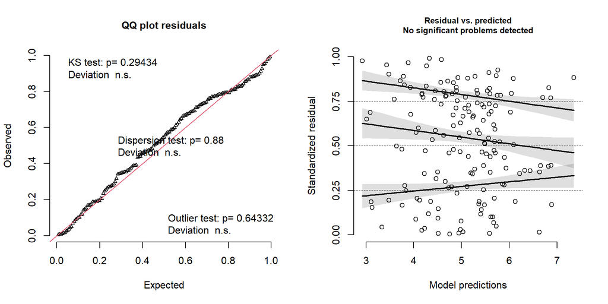

Figure 1: Left: Scaled Residuals QQ Plot for Log-Normal Model. Right: Scaled Residuals vs. Fitted Values Plot for Log-Normal Model.

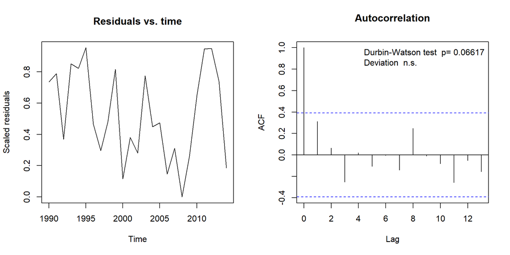

## Negative Binomial (YOY)

The plot below shows that even a YOY Poisson model with the smallest dispersion among all models with up to three-way interaction effects and/or random effects was significantly overdispersed ($H_0: S_{obs}/S_{sim}=1$ vs. $H_1:S_{obs}/S_{sim}>1$, where $S_{obs}$ is the standard deviation of scaled residuals in the fitted model and $S_{sim}$ is the standard deviation scaled residuals assuming the model was correctly specified, $S_{obs}/S_{sim}=21.92$, $p\approx 0$).

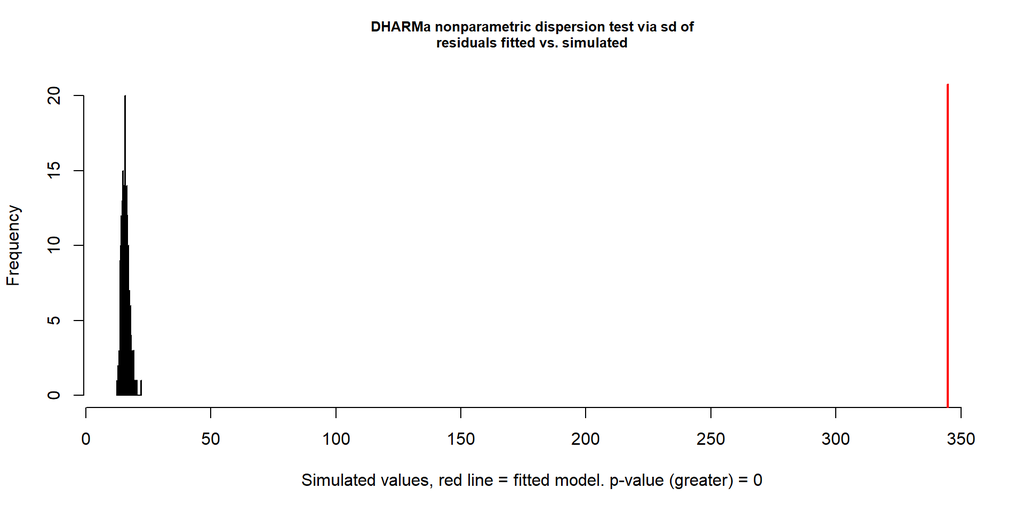

Figure 3: Distribution of Simulated Residual SD (Histogram) vs. Fitted Model Residual SD (Red Line) YOY Counts in Poisson Model.

Similarly, the plot below shows significant underdispersion for a similar YOY negative binomial mixed-effect model that otherwise met assumptions ($H_0: S_{obs}/S_{sim}=1$ vs. $H_1:S_{obs}/S_{sim}<1$ where $S_{\{\cdot\}}$ is defined as above, $S_{obs}/S_{sim}=0.60382$, $p=0.044$).

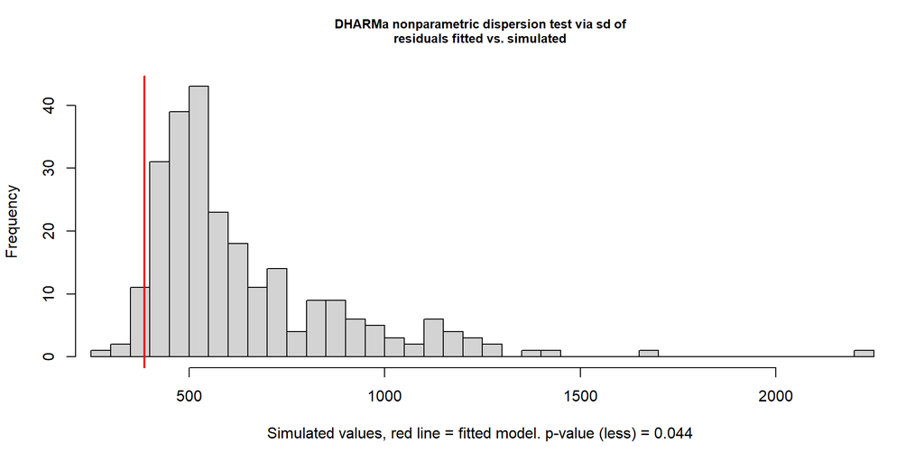

Figure 4: Distribution of Simulated Residual SD (Histogram) vs. Fitted Model Residual SD (Red Line) YOY Counts in Negative Binomial Mixed-Effects Model.

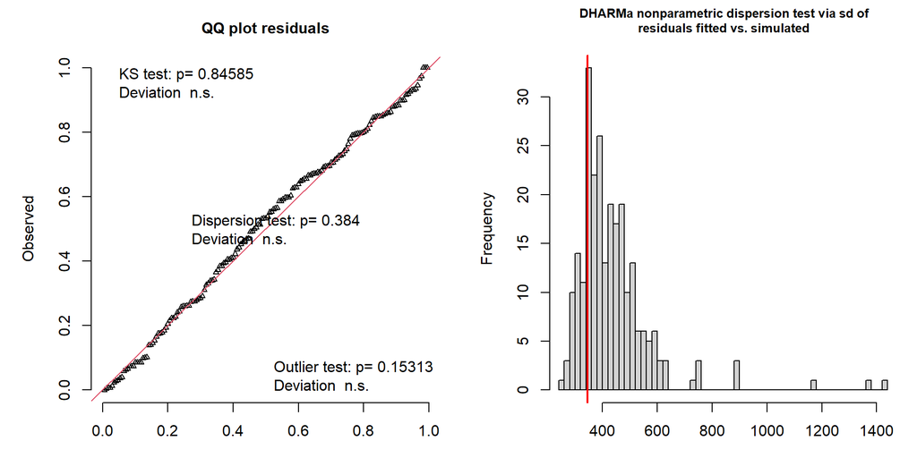

The next plot shows scaled residuals by year, and suggests a cyclical pattern of YOY recruitment with an inconsistent periodicity. A Durbin-Watson test[^2] did not suggest significant temporal autocorrelation among the scaled residuals ($H_0:\rho =0$ vs. $H_1:\rho \neq 0$ where $\rho$ is the autocorrelation between the mean scaled residual for observations at time $t$ and time $t-1$ for each $t$, $p=0.63$). This topic is given a more extensive discussion in the next section.

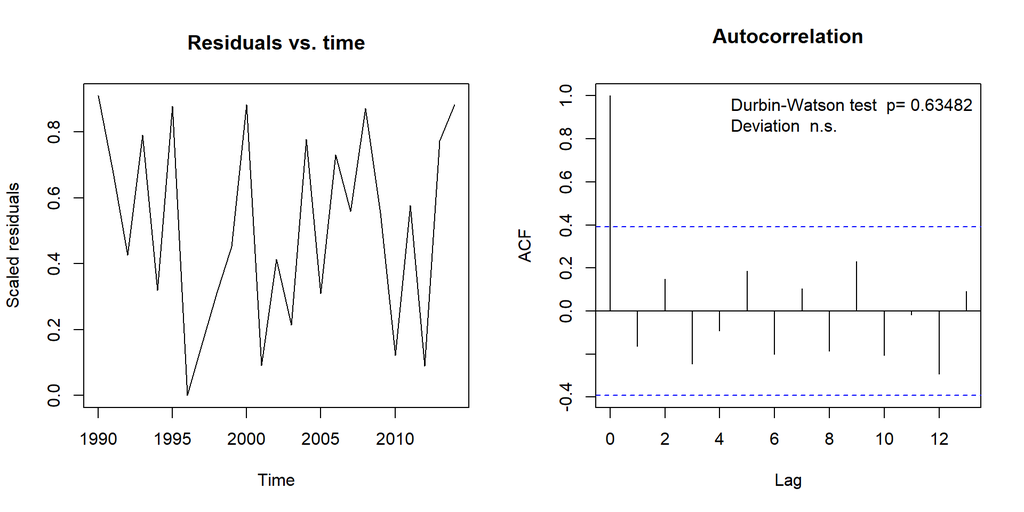

## Zero-Inflated Negative Binomial (JUV)

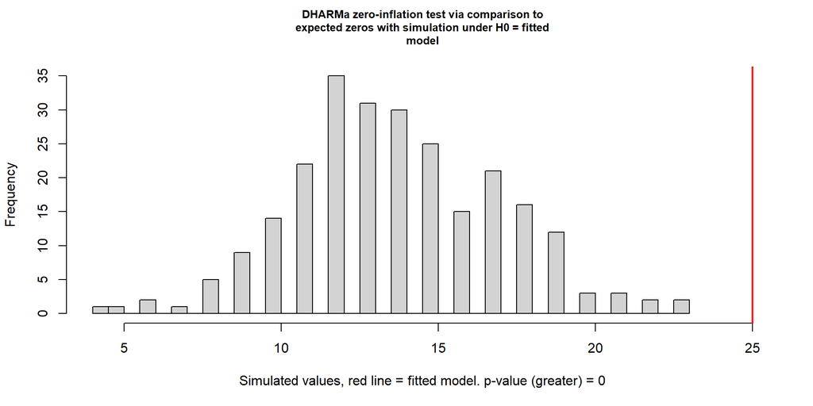

Figure 7: Expected Distribution of Zero-Valued Observations (Histogram) vs. Observed Count (Red Line) for JUV Negative Binomial Mixed-Effects Model

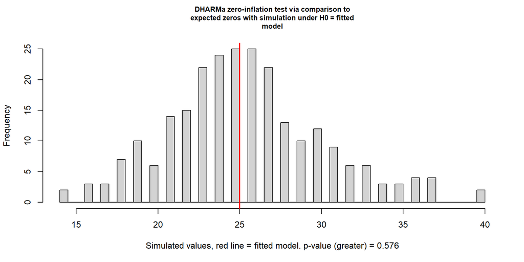

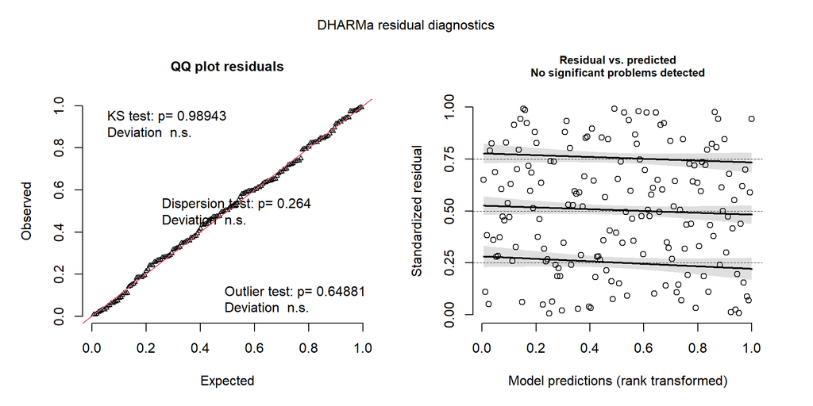

Figure 9: Left: Scaled Residuals QQ Plot for JUV Zero-Inflated Negative Binomial Fixed-Effects Model. Right: Scaled Residuals vs. Fitted Values Plot for JUV Zero-Inflated Negative Binomial Fixed-Effects Model.

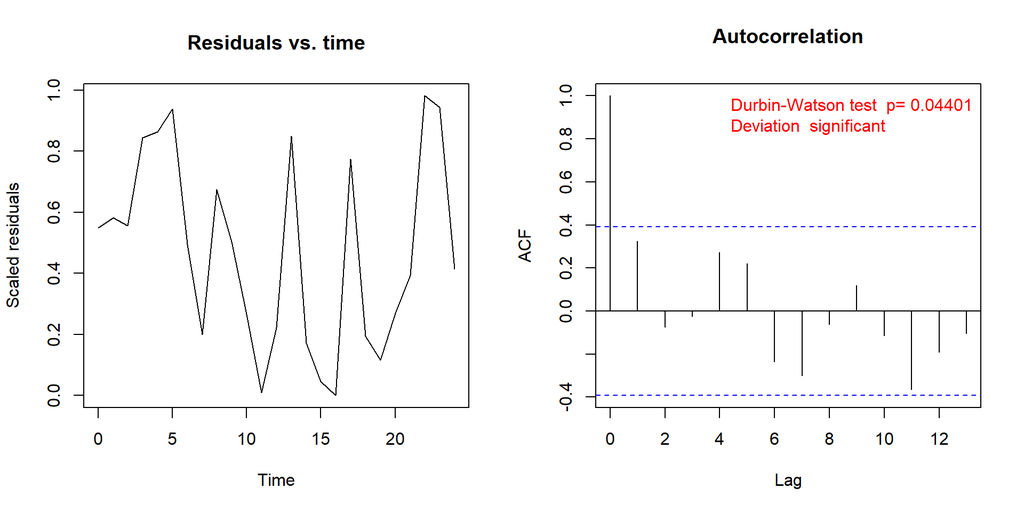

Figure 10: Left: Scaled Residuals by Year for JUV Zero-Inflated Negative Binomial Fixed-Effects Model. Right: Autocorrelation Factor by Lag for JUV Zero-Inflated Negative Binomial Fixed-Effects Model.

# Analysis

## Lake Random Effects

The random effect in the log-normal model shows higher variance (a larger lake effect) than the zero-inflated negative binomial JUV model, which is perhaps expected for two reasons. First, the log-normal model has fewer control parameters, so the lake random effect is doing more; much of the variability that is not explained by year or acreage is “pushed” into the random effect term. Second, the response in the log-normal model is the sum of YOY and JUV recruitment, which will tend to have larger variance overall than a model of JUV alone. Regardless, the random effects in both models are primarily used as controls, and their interpretation is not particularly important.

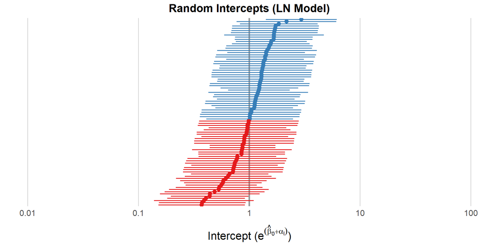

Figure 11: Random Intercepts in Log-Normal Mixed Effect Model with Confidence Intervals

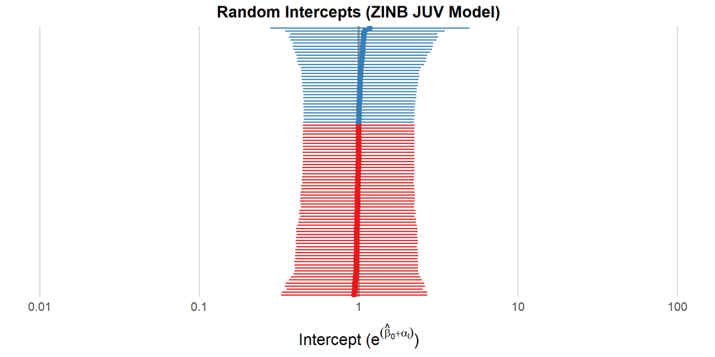

Figure 12: Random Intercepts in Zero-Inflated Negative Binomial Mixed-Effects Model with Confidence Intervals

## Temporal Autocorellation & Recruitment Trends

The main research question is whether there is evidence that YOY and JUV walleye populations are declining. And if there is a decline for a given age of walleye, is that decline steady, and in which types of lakes is the decline occurring? The former question does not have a clear answer. There is some evidence that YOY walleye populations are declining, but given the limits of my analysis along with broader contextual factors, the results are not conclusive. Further, the JUV model does not provide evidence of any overall trend in recruitment, and this non-evidence of a trend is clearer than the evidence of a trend in YOY recruitment.

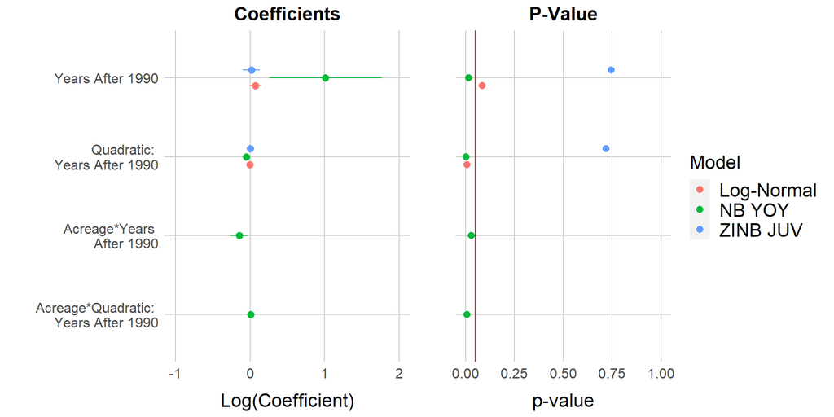

Figure 13: Left: Year After 1990 Coefficients by Model with Confidence Intervals. Right: Year Coefficient P-Values by Model

Finally, as stated in the previous section, a Durbin-Watson test on the zero-inflated JUV model yielded evidence of positive autocorrelation for JUV recruitment. Usually, this result would motivate model reformulation (e.g., some form of time series model). If the goal was predicting future walleye recruitment, then fitting such a model would almost certainly reduce out-of-sample error. However, given the research questions guiding this project, reformulation risks ‘controlling out’ the exact effect the model is intended to detect. The direct meaning of this result is that increased JUV recruitment in a given year tends to be related to higher JUV recruitment in subsequent years, though the exact nature of this relationship is less clear. Neither of the JUV model’s year coefficients are significant, which suggests that there is insufficient evidence to conclude on the existence of an overall trend JUV recruitment. A plausive explanation for this apparent mismatch is that, as shown in the plot below, JUV recruitment varied within a narrow range from the mid-90’s to the early 2010’s. However, like the pre-1996 period, the post-2011 period has seen a slight rise in mean recruitment rates which could easily return to baseline levels in the near future. In other words, the apparent positive autocorrelation could well be an artifact of JUV recruitment’s small variance and a few unusually high-recruitment years happening close together.

While the apparent downward trend in YOY recruitment is concerning at first blush—especially since 152 out of 169 lakes in the dataset used to fit the negative binomial model were below the log-acreage threshold given above—reading too much into this might not be warranted. Or, at the very least, there are reasons to hold out for further research before drawing strong conclusions. First and foremost, “[s]poradic recruitment is common for walleye populations both within and among individual lakes” since “successful recruitment occurs in a given lake every 3-4 years” (Cichosz 2018, pp. 38). While the 2016 WDNR report found that “YOY walleye densities have declined significantly over time in both natural […] and stocked […] model lakes since 1990” (Cichosz 2018, pp. 39), it also noted that “mean recruitment varies dramatically from year to year when data from all lakes are combined” (Cichosz 2018, pp. 38) and the model used to reach these conclusions was limited to the lake’s walleye stocking model, year, and the interaction between the two. To be sure, this is meaningful evidence in support of the decline detected by my models, though the analysis I will present in the next section further complicates this narrative.

Second, specifically in the context of Wisconsin walleye populations, it is not at all clear that models such as the ones used by WDNR or those presented here have any capacity for inference—or, at least, in a durable inference—due to current data collection methods. Hansen et al. (2015) note, that “the predictive capacity of published environment–recruitment correlations have been formally tested using new data, these correlations break down with “disturbing regularity”," citing, “[f]or example, [that] models that rely upon adult stock size to predict recruitment would have limited utility in forecasting recruitment in a large number of lakes, because estimating adult populations is costly and doing so in all lakes in a single year would be impossible” (pp. 662). Consider the two plots below, which shows mean walleye recruitment by year. An analysis using data from 2006 and before would show a strong positive trend in YOY recruitment. However, during the post-2006 period, WDNR has sampled a higher percentage of lakes only once (62% pre-2006 vs. 88% post-2006) but despite these lakes being more variable in size ($\frac{Var(\text{Acreage}_{Post-06})}{Var(\text{Acreage}_{Pre-06})}=$ 1.55), they had lower ($\frac{Avg(\text{YOY Per Acre}_{Post-06})}{Avg(\text{YOY Per Acre}_{Pre-06})}=$ 0.42) and less varied ($\frac{Var(\text{YOY Per Acre}_{Post-06})}{Var(\text{YOY Per Acre}_{Pre-06})}=$ 0.46) YOY density. In other words, the current trend could be due in part to the irregular and random structure of WDNR’s electrofishing sampling; they could simply have sampled a higher-than-normal proportion of lakes of various sizes in which YOY density is below average.

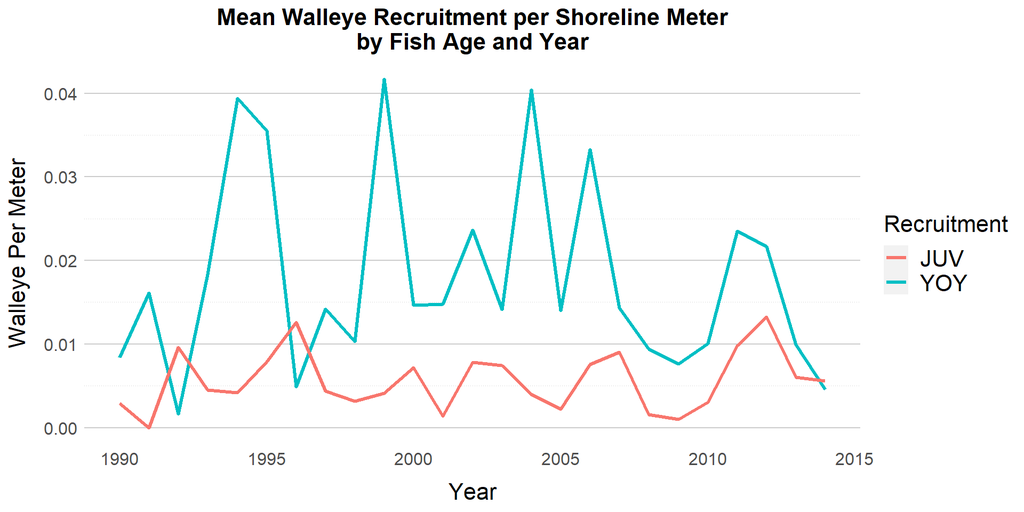

Figure 14: Mean Walleye Recruitment per Shoreline Meter Surveyed By Age and Year

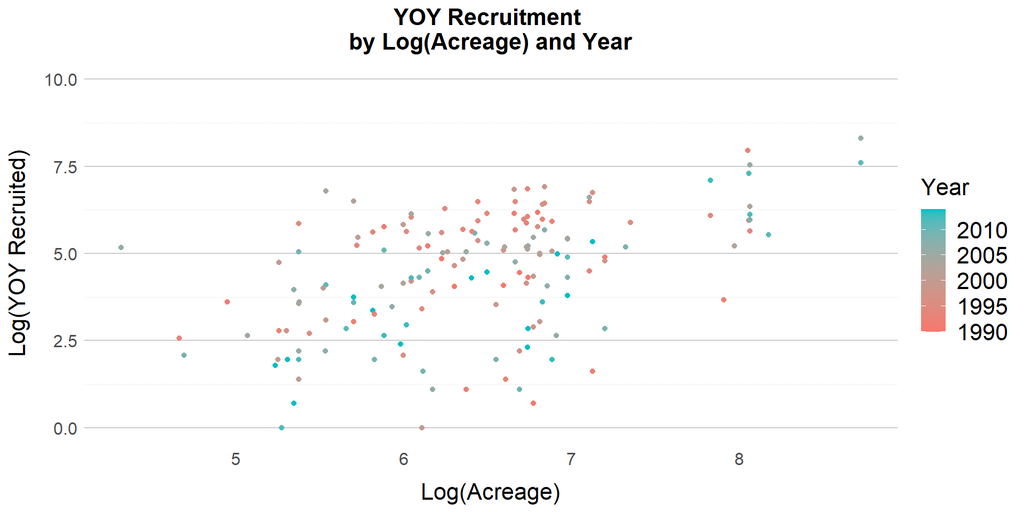

Figure 15: Log(YOY Caught) vs. Log(Acreage) by Year

## Lake Types

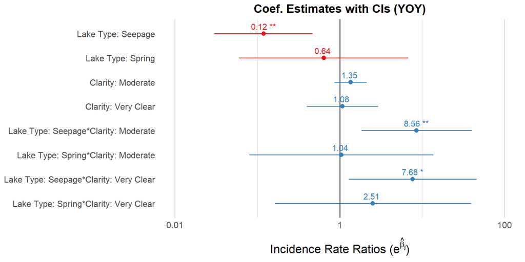

Figure 16: Lake Type Coefficients for YOY Negative Binomial Model

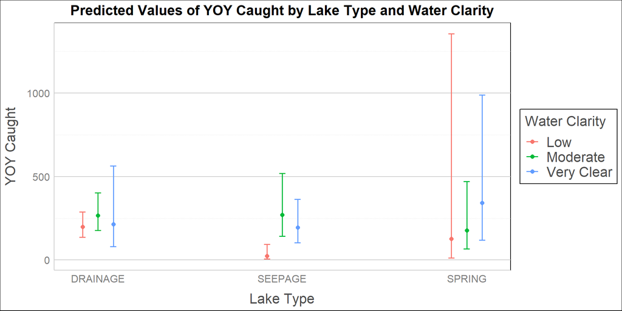

Figure 17: Predicted Values for Lake Type/Water Clarity Interaction (YOY Model)

Given the lack of a temporal trend found for JUV walleye, any lake type/water clarity pattern is likely to instead reflect pre-existing differences between lakes and lake types. The coefficient plot below shows that all spring lake—which have an outlet but no inlet—were found to be significant; low-clarity spring lakes had lower baseline JUV catch rates relative to low-clarity drainage lakes, while moderate and high-clarity spring lakes had higher JUV catch rates. In addition, very clear drainage lakes had low JUV catch rates, while moderate and very clear seepage lakes had higher JUV catch rates, similar to the YOY model. This set of results is somewhat surprising in that it contrasts with Hansen et al’s (2015) random forest model, which found that hydraulic type was among the least important factors in determining a lake’s walleye population (mean importance: 9.27/100) (pp. 665). However, given the lack of evidence for a temporal trend in JUV recruitment, one plausible explanation for this result is that the lake type and water clarity terms are capturing the effects of temperature, since lake types are dispersed unequally across Wisconsin’s latitudes (Cichosz 2011). These different latitudes have felt differential effects from climate change, though the trends have been relatively constant across similar latitudes (G. J. A. Hansen et al. 2017).

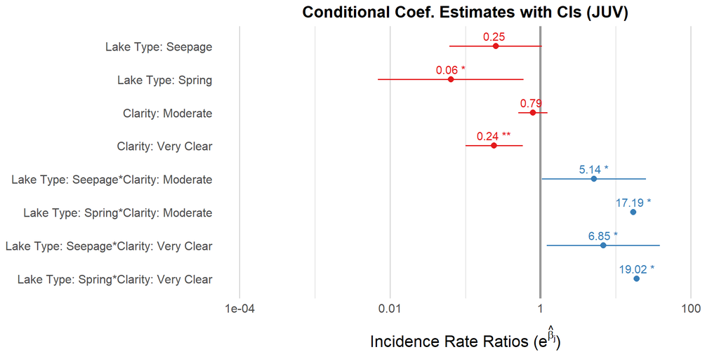

Figure 18: Lake Type Coefficients for JUV Model.

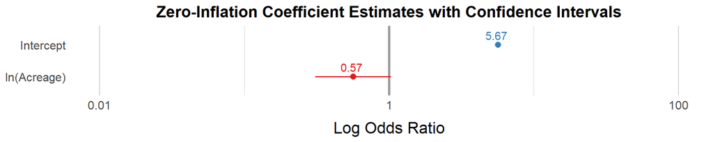

Figure 19: Zero Inflation Model Coefficients for JUV Model.

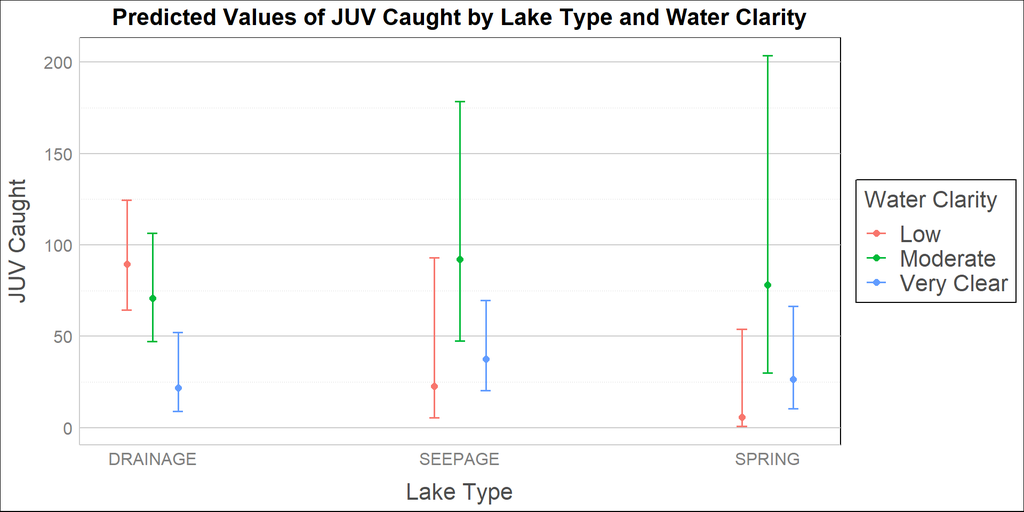

Figure 20: Predicted Values for Lake Type/Water Clarity Interaction for JUV Model.

# Discussion & Conclusion

The results clearly suggest that something is changing with Wisconsin’s age-0 and age-1 walleye populations, though the exact details of what remain tenuous. The finding that the state’s age-0 walleye populations appear to be declining is not new. The limitations of my analysis notwithstanding, these findings are best viewed in the wider context of declining biodiversity in a changing climate. Yet the fact that this decline in wildlife populations—walleye and others—seems to be increasingly rapid is a mere footnote outside of academic and conservation circles. Even there, it seems to be a foregone conclusion as authors debate how to address the magnitude of this escalating decline (G. J. A. Hansen et al. 2017) or the interaction of this decline between populations (G. Hansen, Midway, and Wagner 2017). Similarly, much of the explicit discussion about age-1 and older walleye has been limited trends in fish size (Pedersen et al. 2018) or broader fisheries management (G. Hansen, Gaeta, et al. 2015).

Two major limitations of this analysis concern holes in the provided data. First WDNR manually stocks certain lakes with walleye, while others are naturally stocked. These different stocking methods have some effect on age-0 and walleye populations, and the effect of these stocking methods on walleye has changed across years (Cichosz 2018). The stocking status of each lake was not included in the data set with which this project was prepared, but offers a possible extension of the research presented here. Similarly, the extent to which fisheries are exploited is a significant factor in their sustainability. While a certain amount of fishing is allowed by law, over-fishing can drop fisheries below replenishment level leading to long-term declines in recruitment. WDNR estimates exploitation levels broadly for use in setting harvest levels, and fishing is explicitly restricted in low-population lakes (Cichosz 2018). Data on the exploitation level of the lakes analyzed would allow me to determine how much of the apparent decline in age-0 walleye populations is concentrated in lakes with over-exploited walleye populations.

Perhaps the most concerning result, though, is the shift in baselines. Much of the previous section was concerned with rates of change. However, the final part—on baseline recruitment in lake types—begs a major question: what were the walleye populations like in Wisconsin’s lakes before WDNR began collecting data in 1990? If the caveats discussed above are merely incidental and walleye stocks are indeed declining, then Wisconsin may well be experiencing an increasingly common phenomenon: shifting baselines.

> [W]hat we think of as normal and healthy–the baseline–has had to shift to keep up with reality. Our picture of the environment becomes skewed, as we forget what used to be and adjust unconsciously to a diminished present. […] We adjust our baseline to the new level, and we don’t recall what was there. If you generalize this, something like this happens. You have on the y axis some good thing: biodiversity, numbers of orca, the greenness of your country, the water supply. And over time it changes — it changes because people do things, or naturally. Every generation will use the images that they got at the beginning of their conscious lives as a standard and will extrapolate forward. And the difference then, they perceive as a loss. But they don’t perceive what happened before as a loss. You can have a succession of changes. At the end you want to sustain miserable leftovers. (Walsh 2013)

# References

Bates, Douglas, Martin Mächler, Ben Bolker, and Steve Walker. 2015. “Fitting Linear Mixed-Effects Models Using lme4.” *Journal of Statistical Software* 67 (1): 1–48. https://doi.org/10.18637/jss.v067.i01.

Bolker, Ben. 2015. “"Using Glmer.nb(), the Error Message:(Maxstephalfit) Pirls Step-Halvings Failed to Reduce Deviance in pwrssUpdate Is Returned".” Stack Overflow. https://stackoverflow.com/questions/28036334/using-glmer-nb-the-error-messagemaxstephalfit-pirls-step-halvings-failed-t?answertab=active#tab-top. https://stackoverflow.com/a/28037767/13374906.

Brezonik, Patrick, Leif Olmanson, Marvin E. Bauer, and Steven Kloiber. 2007. “Measuring Water Clarity and Quality in Minnesota Lakes and Rivers: A Census-Based Approach Using Remote-Sensing Techniques.” *CURA Reporter* 37 (2): 3–13.

Brooks, Mollie E., Kasper Kristensen, Koen J. van Benthem, Arni Magnusson, Casper W. Berg, Anders Nielsen, Hans J. Skaug, Martin Maechler, and Benjamin M. Bolker. 2017. “glmmTMB Balances Speed and Flexibility Among Packages for Zero-Inflated Generalized Linear Mixed Modeling.” *The R Journal* 9 (2): 378–400. https://journal.r-project.org/archive/2017/RJ-2017-066/index.html.

Cichosz, Thomas A. 2011. “Wisconsin Department of Natural Resources 2008-2009 Ceded Territory Fishery Assessment Report.” Wisconsin Department of Natural Resources Bureau of Fisheries Management.

———. 2018. “Wisconsin Department of Natural Resources 2016-2017 Ceded Territory Fishery Assessment Report.”

Dvoretzky, A., J. Kiefer, and J. Wolfowitz. 1956. “Asymptotic Minimax Character of the Sample Distribution Function and of the Classical Multinomial Estimator.” *Ann. Math. Statist.* 27 (3): 642–69. https://doi.org/10.1214/aoms/1177728174.

Hansen, Gretchen, Stephen Carpenter, Jereme Gaeta, Joseph Hennessy, and Jake Vander Zanden. 2015. “Predicting Walleye Recruitment as a Tool for Prioritizing Management Actions.” *Canadian Journal of Fisheries and Aquatic Sciences* 72 (February): 661–72. https://doi.org/10.1139/cjfas-2014-0513.

Hansen, Gretchen, Jereme Gaeta, Jonathan Hansen, and Stephen Carpenter. 2015. “Learning to Manage and Managing to Learn: Sustaining Freshwater Recreational Fisheries in a Changing Environment.” *Fisheries* 40 (February): 56–64. https://doi.org/10.1080/03632415.2014.996804.

Hansen, Gretchen J. A., Jordan S. Read, Jonathan F. Hansen, and Luke A. Winslow. 2017. “Projected Shifts in Fish Species Dominance in Wisconsin Lakes Under Climate Change.” *Global Change Biology* 23 (4): 1463–76. https://doi.org/10.1111/gcb.13462.

Hansen, Gretchen, Stephen Midway, and Tyler Wagner. 2017. “Walleye Recruitment Success Is Less Resilient to Warming Water Temperatures in Lakes with Abundant Largemouth Bass Populations.” *Canadian Journal of Fisheries and Aquatic Sciences* 75 (April). https://doi.org/10.1139/cjfas-2016-0249.

Hansen, Michael J., Steven P. Newman, and Clayton J. Edwards. 2004. “A Reexamination of the Relationship Between Electrofishing Catch Rate and Age-0 Walleye Density in Northern Wisconsin Lakes.” *North American Journal of Fisheries Management* 24 (2): 429–39. https://doi.org/10.1577/M03-014.1.

Hartig, Florian. 2020a. *DHARMa: Residual Diagnostics for Hierarchical (Multi-Level / Mixed) Regression Models*. https://CRAN.R-project.org/package=DHARMa.

———. 2020b. *TestTemporalAutocorrelation: Test for Temporal Autocorrelation*. https://rdrr.io/cran/DHARMa/man/testTemporalAutocorrelation.html.

Mason, S. J., and N. E. Graham. 2002. “Areas Beneath the Relative Operating Characteristics (Roc) and Relative Operating Levels (Rol) Curves: Statistical Significance and Interpretation.” *Quarterly Journal of the Royal Meteorological Society* 128 (584): 2145–66. https://doi.org/10.1256/003590002320603584.

Pedersen, Eric J, Daisuke Goto, Jereme W Gaeta, Gretchen JA Hansen, Greg G Sass, M Jake Vander Zanden, Thomas A Cichosz, and Andrew L Rypel. 2018. “Long-Term Growth Trends in Northern Wisconsin Walleye Populations Under Changing Biotic and Abiotic Conditions.” *Canadian Journal of Fisheries and Aquatic Sciences* 75 (5): 733–45.

Walsh, Bryan. 2013. “Shifting Baselines: Why the Environment Is Even Worse Off Than You Think.” Time Magazine. https://science.time.com/2013/08/01/shifting-baselines-why-the-environment-is-even-worse-off-than-you-think/.

# Appendix: Binomial Classifier for Sustainable YOY Recruitment

## Motivation & Model

The model was based on the log-normal models found in WDNR’s annual Ceded Territory fishery assessment reports. In that spirit, the model included a fixed effect for the natural logarithm of lake size (in acres) and a random effect for each lake. There are two differences between my ME model and the log-normal WDNR model. First, because the ME model is not intended to estimate mean walleye *population* (as is the case for WDNR’s log-linear model), but rather to predict the whether YOY walleye are *sampled* (“recruited”) at a rate indicating sustainability, I additionally control for the effect of survey temperature due to the effect it has on sampling rates (G. Hansen, Carpenter, et al. 2015). Further, I included a quadratic fixed-effect term for survey year (in addition to the linear term in the WDNR model) in order to account for changes in the overall trend of walleye recruitment.

```r
b2 <- glmer(recruit_yoy~
             I(s_year)+I(s_year^2)+
             size_acre+
             temp_survey+
        (1|wbic),
      data=ft, nAGQ=0,
      family = binomial(link="logit"),
      control = glmerControl(optimizer ='optimx',
                optCtrl=list(method='L-BFGS-B')))
```

This model is parameterized as follows:

$$\begin{align*}
ln\left( \frac{\pi_{i\ell}}{1-\pi_{i\ell}} \right) &= \beta_0 + \alpha_\ell + \beta_1 ln(\text{Acreage}_i) + \beta_2 \text{Survey Temperature}_i\\
&\qquad + \beta_3 \text{(Years after 1990)}_i + \beta_4 \text{(Years after 1990)}^2_i
\end{align*}$$

It is worth setting out the motivation for testing the accuracy of the models using receiver operating characteristic (ROC) curves. Simply put, even though the dataset contains a balanced successful/unsuccessful recruitment ratio, it is likely that the ratio is unbalanced across all lakes. This is even more likely when accounting for the presence of unreliable surveys, which were removed from the dataset for this analysis. Mere accuracy is not enough for a model to be worth considering when successes and failures are unbalanced in the population; given a different dataset with proportion of successful recruitments $p$, naively guessing that a recruitment was successful (if $p>0.5$) or unsuccessful (if $p<0.5$) will yield better-than-random accuracy.